# Walkthroughs and Exercises for Deep Learning for Business Made Simple

Author

[Dr. Chester Ismay](https://chester.rbind.io)

```python
# Run this once per session, then RESTART the runtime if
# Colab prompts you to. Colab already ships torch; we
# add/upgrade Keras 3 and the datasets library.
!pip install -q -U keras datasets
!pip install -q scikit-learn matplotlib pillow
```

```python
# Run this setup cell FIRST. The backend must be chosen
# BEFORE keras is imported.
import os
os.environ["KERAS_BACKEND"] = "torch"

import keras
import numpy as np
import pandas as pd

# Display all columns and all outputs from each cell
pd.set_option("display.max_columns", None)
keras.utils.set_random_seed(2026)
print("Keras", keras.__version__, "on backend:",
      keras.backend.backend())
```

```
Keras 3.15.1 on backend: torch
```

# Intro: Getting Started with Deep Learning for Business

In this course we use **Keras 3**, a friendly, high-level deep learning API, running on the **PyTorch** backend. You write simple Keras code; PyTorch does the computation underneath. Every walkthrough also includes an **idiomatic PyTorch** version so you can see what the same model looks like in raw PyTorch.

## One Keras, three engines (TensorFlow, PyTorch, or JAX)

Keras 3 is **engine-agnostic**: the *same* model code runs on **TensorFlow**, **PyTorch**, or **JAX**. You choose the engine once per session by setting `KERAS_BACKEND` **before** importing Keras; nothing else in this course changes. We use PyTorch here, to run any of it on TensorFlow instead, you’d change one line in the setup cell and restart the runtime:

```
%%{init: {'theme': 'base', 'themeVariables': {'fontSize': '16px'}, 'flowchart': {'nodeSpacing': 90}}}%%
flowchart TD
  C(["Your Keras 3 code"]):::proc --> E{"KERAS_BACKEND ?"}:::decision
  E -->|tensorflow| F["TensorFlow"]:::eng
  E -->|torch| T["PyTorch"]:::engUsed
  E -->|jax| J["JAX"]:::eng
  F --> R(["Same model,<br/>runs unchanged"]):::good
  T --> R
  J --> R
  classDef proc fill:#dbe9ff,stroke:#1a73e8,color:#1a1a1a
  classDef decision fill:#fff3cd,stroke:#d39e00,color:#1a1a1a
  classDef eng fill:#e6e0ff,stroke:#6a1b9a,color:#1a1a1a
  classDef engUsed fill:#cdb8ff,stroke:#5b1690,stroke-width:3px,color:#1a1a1a
  classDef good fill:#d8f5d8,stroke:#2e7d32,color:#1a1a1a
```

You write Keras 3 once; one setting picks the engine that runs it (PyTorch here).

A quick aside on the three engines, since you will hear all of them mentioned. Here is the short version of when each one shines:

| Engine | Strengths | Trade-offs |
| --- | --- | --- |
| **PyTorch** *(our choice)* | Pythonic, easy to debug; huge model and tutorial ecosystem; now common in industry | Serving tooling historically less turnkey than TensorFlow |
| **TensorFlow** | Mature deployment (TF Serving, TFLite, on-device); proven at scale | More boilerplate; less handy for quick, interactive work |
| **JAX** | Very fast on TPUs; composable `jit`, `grad`, `vmap` for research | Smaller ecosystem; steeper curve; least beginner-friendly |

We use **PyTorch** because it is the friendliest to learn and debug and the backend you are most likely to meet on the job. Because Keras 3 is engine-agnostic, it is a low-stakes choice either way.

```python
# To run this course on the TensorFlow engine instead of
# PyTorch, set this BEFORE `import keras`, then restart the
# runtime (the engine is locked in once Keras imports).
import os
os.environ["KERAS_BACKEND"] = "tensorflow"   # was "torch"
```

```python
# Whichever engine is active, this is how you check it:
print("Active Keras engine:", keras.backend.backend())
```

```
Active Keras engine: torch
```

Keras can also target: `tensorflow`, `torch`, and `jax`.

> **Why this matters for you:** you learn *one* high-level API and stay portable. If your team standardizes on TensorFlow (or JAX) later, your Keras code comes along, only the one-line engine setting changes.

## Walkthrough 0.1: Setting Up Keras (PyTorch backend) and Your First Tensor

### Confirm the environment

```python
import keras, torch
# should say 'torch'
print("Keras backend:", keras.backend.backend())
print("PyTorch version:", torch.__version__)
```

```
Keras backend: torch
PyTorch version: 2.14.0+cpu
```

> **Common Pitfall:** `os.environ["KERAS_BACKEND"] = "torch"` must run **before** `import keras`. If you import keras first and then set it, you’ll silently get the default backend. When in doubt, restart the kernel and run the setup cell first.

### A first tensor operation

```python
# A tensor is just an array the framework can run fast math
# on (and learn from)
x = keras.ops.array([[1.0, 2.0], [3.0, 4.0]])
print("Sum of all elements:", float(keras.ops.sum(x)))
print("Column means:", keras.ops.mean(x, axis=0))
```

```
Sum of all elements: 10.0
Column means: tensor([2., 3.])
```

## Exercise 0.1: Confirm Your Environment

```python
# Build a tiny one-line "model" and run data through it:
# proves the stack works
layer = keras.layers.Dense(1, activation="sigmoid")
out = layer(keras.ops.array([[0.5, -1.2, 3.0]]))
print("Output shape:", out.shape)
```

```
Output shape: torch.Size([1, 1])
```

If you see a `(1, 1)` tensor above, you are ready to go.

> **GenAI tip:** If a setup cell errors, copy the *full* error plus one line of context (“I’m using Keras 3 with the PyTorch backend on Colab”) into your AI assistant and ask for the fix. Re-run to confirm, never trust a fix you haven’t re-run.

# Module 1: Demystifying Neural Networks for Business Insight

We’ll predict **hotel booking cancellations**, a real revenue-management problem. Every cancellation is a room you could have sold. The dataset has ~119,000 real bookings.

## Walkthrough 1.1: Predicting Booking Cancellations with a Neural Network

### Load and inspect the data

```python
url = ("https://raw.githubusercontent.com/rfordatascience/tidytuesday/master/"
       "data/2020/2020-02-11/hotels.csv")
hotels = pd.read_csv(url)
print(hotels.shape)
hotels[["hotel", "lead_time", "adults", "previous_cancellations",
        "adr", "is_canceled"]].head()
```

```
(119390, 32)
```

|  | hotel | lead_time | adults | previous_cancellations | adr | is_canceled |
| --- | --- | --- | --- | --- | --- | --- |
| 0 | Resort Hotel | 342 | 2 | 0 | 0.0 | 0 |
| 1 | Resort Hotel | 737 | 2 | 0 | 0.0 | 0 |
| 2 | Resort Hotel | 7 | 1 | 0 | 75.0 | 0 |
| 3 | Resort Hotel | 13 | 1 | 0 | 75.0 | 0 |
| 4 | Resort Hotel | 14 | 2 | 0 | 98.0 | 0 |

**Data dictionary** (click to expand): the hotel-booking columns we use**

| Column | Type | What it stores |
| --- | --- | --- |
| `hotel` | text | Property type: “City Hotel” or “Resort Hotel” |
| `lead_time` | integer | Days between the booking and the arrival date |
| `stays_in_weekend_nights` | integer | Weekend nights (Sat/Sun) in the stay |
| `stays_in_week_nights` | integer | Weeknights (Mon to Fri) in the stay |
| `adults` | integer | Number of adults on the booking |
| `previous_cancellations` | integer | Earlier bookings this guest had canceled |
| `booking_changes` | integer | Changes made to the booking after it was placed |
| `total_of_special_requests` | integer | Count of special requests (e.g., a high floor) |
| `adr` | float | Average daily rate: the average price per night |
| `is_canceled` | binary (0/1) | Target: 1 if the booking was canceled, 0 if kept |

```python
# How often do guests cancel? (our target)
hotels["is_canceled"].value_counts(normalize=True).round(3)
```

```
is_canceled
0    0.63
1    0.37
Name: proportion, dtype: float64
```

### Prepare the features

```
%%{init: {'theme': 'base', 'themeVariables': {'fontSize': '16px'}}}%%
flowchart TD
  TR[("Training set")]:::data --> SC["Compute mean & std<br/>on TRAIN only"]:::key
  SC --> AP["Apply the same numbers<br/>to BOTH splits"]:::proc
  AP --> TS[/"Scaled training"/]:::good
  AP --> VS[/"Scaled validation"/]:::good
  classDef data fill:#d1f0ec,stroke:#0b7a75,color:#1a1a1a
  classDef key fill:#fff3cd,stroke:#d39e00,stroke-width:2px,color:#1a1a1a
  classDef proc fill:#dbe9ff,stroke:#1a73e8,color:#1a1a1a
  classDef good fill:#d8f5d8,stroke:#2e7d32,color:#1a1a1a
```

Fit the scaler on training data only, then apply it to both splits. Computing it on all the data leaks the future.

```python
# A handful of numeric drivers a revenue manager would
# recognize
features = ["lead_time", "stays_in_weekend_nights", "stays_in_week_nights",
            "adults", "previous_cancellations", "booking_changes",
            "total_of_special_requests", "adr"]

data = hotels[features + ["is_canceled"]].dropna().copy()
X = data[features].values.astype("float32")
y = data["is_canceled"].values.astype("float32")

from sklearn.model_selection import train_test_split
X_train, X_val, y_train, y_val = train_test_split(
    X, y, test_size=0.2, random_state=2026, stratify=y)

# Neural networks train far better on standardized inputs.
# Fit the shift/scale on the TRAINING data only, then apply
# the SAME numbers to validation (see the pitfall below).
mean, std = X_train.mean(axis=0), X_train.std(axis=0) + 1e-8
X_train = (X_train - mean) / std
X_val = (X_val - mean) / std
print("Train:", X_train.shape, "Validation:", X_val.shape)
```

```
Train: (95512, 8) Validation: (23878, 8)
```

> **Common Pitfall:** Standardize using statistics from the **training** data only, then apply the same shift/scale to validation and new data. Computing the mean on all the data leaks information about the future into training.

### Build, train, and evaluate the network

```
%%{init: {'theme': 'base', 'themeVariables': {'fontSize': '16px'}}}%%
flowchart LR
  I[/"8 booking<br/>features"/]:::data --> H1["Dense 32<br/>specialists"]:::proc
  H1 --> H2["Dense 16<br/>combine"]:::proc
  H2 --> O[/"Cancel<br/>probability"/]:::good
  classDef data fill:#d1f0ec,stroke:#0b7a75,color:#1a1a1a
  classDef proc fill:#dbe9ff,stroke:#1a73e8,color:#1a1a1a
  classDef good fill:#d8f5d8,stroke:#2e7d32,color:#1a1a1a
```

Business inputs flow through hidden ‘specialist’ layers into one cancellation probability.

```python
model = keras.Sequential([
    keras.layers.Input(shape=(len(features),)),
    # a "team of specialists"
    keras.layers.Dense(32, activation="relu"),
    keras.layers.Dense(16, activation="relu"),
    # probability of cancellation
    keras.layers.Dense(1, activation="sigmoid"),
])
model.compile(optimizer="adam", loss="binary_crossentropy",
              metrics=["accuracy"])
model.summary()
```

```
Model: "sequential"
```

```
┏━━━━━━━━━━━━━━━━━━━━━━━━━━━━━━━━━┳━━━━━━━━━━━━━━━━━━━━━━━━┳━━━━━━━━━━━━━━━┓
┃ Layer (type)                    ┃ Output Shape           ┃       Param # ┃
┡━━━━━━━━━━━━━━━━━━━━━━━━━━━━━━━━━╇━━━━━━━━━━━━━━━━━━━━━━━━╇━━━━━━━━━━━━━━━┩
│ dense_1 (Dense)                 │ (None, 32)             │           288 │
├─────────────────────────────────┼────────────────────────┼───────────────┤
│ dense_2 (Dense)                 │ (None, 16)             │           528 │
├─────────────────────────────────┼────────────────────────┼───────────────┤
│ dense_3 (Dense)                 │ (None, 1)              │            17 │
└─────────────────────────────────┴────────────────────────┴───────────────┘
```

```
 Total params: 833 (3.25 KB)
```

```
 Trainable params: 833 (3.25 KB)
```

```
 Non-trainable params: 0 (0.00 B)
```

```
%%{init: {'theme': 'base', 'themeVariables': {'fontSize': '17px'}}}%%
flowchart LR
  P["Predict"]:::proc --> M["Measure error<br/>= loss"]:::bad
  M --> A["Adjust weights<br/>= optimizer"]:::accent
  A -->|repeat each epoch| P
  classDef proc fill:#dbe9ff,stroke:#1a73e8,color:#1a1a1a
  classDef bad fill:#fde0e0,stroke:#c62828,color:#1a1a1a
  classDef accent fill:#ede0ff,stroke:#6a1b9a,color:#1a1a1a
```

Training is a loop: predict, measure how wrong, adjust, and repeat.

```python
history = model.fit(X_train, y_train,
                    validation_data=(X_val, y_val),
                    epochs=10, batch_size=256, verbose=0)
print("Final validation accuracy:",
      round(float(history.history["val_accuracy"][-1]), 3))
```

```
Final validation accuracy: 0.758
```

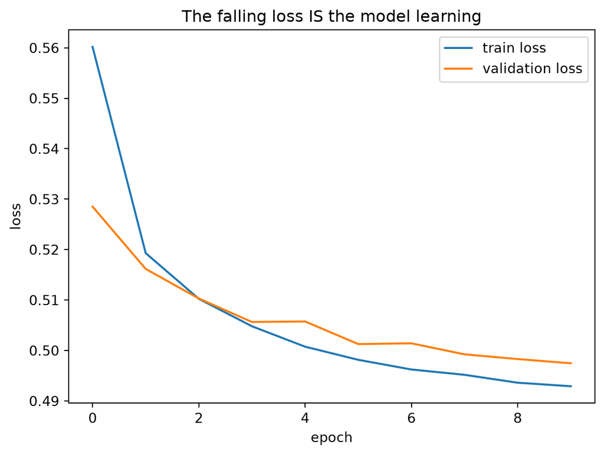

```python
import matplotlib.pyplot as plt
plt.plot(history.history["loss"], label="train loss")
plt.plot(history.history["val_loss"],
         label="validation loss")
plt.xlabel("epoch"); plt.ylabel("loss"); plt.legend()
plt.title("The falling loss IS the model learning")
plt.show();
```

### Visualize: can the model tell the two groups apart?

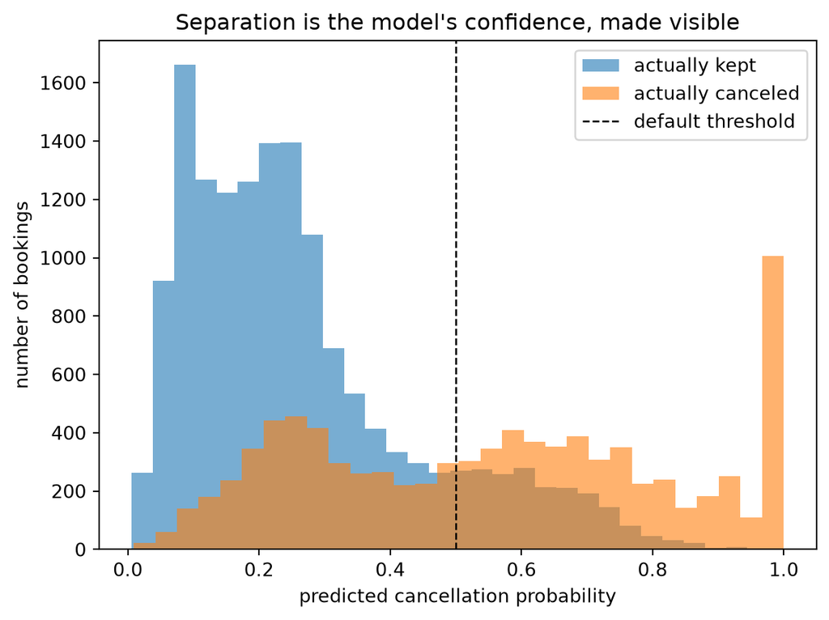

```python
# A model that "separates" the classes pushes cancellations
# toward 1 and the rest toward 0. Overlapping histograms =
# an indecisive model.
val_probs = model.predict(X_val, verbose=0).ravel()
plt.hist(val_probs[y_val == 0], bins=30, alpha=0.6,
         label="actually kept")
plt.hist(val_probs[y_val == 1], bins=30, alpha=0.6,
         label="actually canceled")
plt.axvline(0.5, color="k", ls="--", lw=1,
            label="default threshold")
plt.xlabel("predicted cancellation probability")
plt.ylabel("number of bookings")
plt.legend()
plt.title("Separation is the model's confidence, made visible")
plt.show();
```

### The same model in idiomatic PyTorch (reference)

```python
import torch
import torch.nn as nn
from torch.utils.data import TensorDataset, DataLoader

# Convert the same train/val arrays into PyTorch tensors
# (the "_t" = tensor version).
X_train_t = torch.tensor(X_train)
# shape (N,) -> (N, 1) to match the model output
y_train_t = torch.tensor(y_train).unsqueeze(1)
X_val_t = torch.tensor(X_val)
y_val_t = torch.tensor(y_val).unsqueeze(1)

# Idiomatic PyTorch feeds the model mini-batches via a
# DataLoader
train_loader = DataLoader(
    TensorDataset(X_train_t, y_train_t), batch_size=256,
    shuffle=True)

net = nn.Sequential(
    nn.Linear(len(features), 32), nn.ReLU(),
    nn.Linear(32, 16), nn.ReLU(),
    # outputs a raw score ("logit"), not a probability
    nn.Linear(16, 1),
)
optimizer = torch.optim.Adam(net.parameters(), lr=1e-3)
# applies the sigmoid for us, more numerically stable
loss_fn = nn.BCEWithLogitsLoss()

# Train: loop over the data 10 times, one gradient step per
# mini-batch
for epoch in range(10):
    net.train()
    for x_batch, y_batch in train_loader:
        # clear last step's gradients
        optimizer.zero_grad()
        # how wrong are we?
        loss = loss_fn(net(x_batch), y_batch)
        # measure how to improve
        loss.backward()
        # nudge the weights
        optimizer.step()

# Evaluate, one readable step at a time
net.eval()
with torch.no_grad():
    logits = net(X_val_t)                     # raw scores
    # turn scores into probabilities
    probs = torch.sigmoid(logits)
    # 1 if "canceled", else 0
    predicted = (probs > 0.5).float()
    # 1 where the prediction matches the truth
    correct = (predicted == y_val_t).float()
    # fraction correct
    val_acc = correct.mean().item()
print("PyTorch validation accuracy:", round(val_acc, 3));
```

```
PyTorch validation accuracy: 0.757
```

> **Notice:** Keras handled the training loop for you; in raw PyTorch you write the `DataLoader` and the `zero_grad -> forward -> loss -> backward -> step` loop yourself. Same model, same mini-batching, just more control and more code.

> One difference to call out: the Keras model ended in a `sigmoid`, but the PyTorch model outputs a raw score (a “logit”). That’s the PyTorch convention, `BCEWithLogitsLoss` folds the sigmoid in for numerical stability, so we apply `sigmoid` ourselves only when we want a probability at the end.

> **Prefer TensorFlow?** The same model is identical save for the prefix, e.g. `tf.keras.Sequential([...])`, since Keras 3 *is* the API TensorFlow exposes. Like the Keras code above it hands you `.fit()`; only the lower-level PyTorch version needs a hand-written loop.

## Exercise 1.1: Predicting Average Daily Rate (Regression)

Now the target is a **number**, the average daily rate (`adr`), i.e. price. The same network shape works; we just change the last layer and the loss.

```
%%{init: {'theme': 'base', 'themeVariables': {'fontSize': '16px'}}}%%
flowchart TD
  B["Same network body"]:::proc --> Q{"Predicting<br/>what?"}:::decision
  Q -->|Yes / No| C["Sigmoid + cross-entropy<br/>probability, 0 to 1"]:::good
  Q -->|A number| R["No activation + MSE<br/>any dollar value"]:::accent
  classDef proc fill:#dbe9ff,stroke:#1a73e8,color:#1a1a1a
  classDef decision fill:#fff3cd,stroke:#d39e00,color:#1a1a1a
  classDef good fill:#d8f5d8,stroke:#2e7d32,color:#1a1a1a
  classDef accent fill:#ede0ff,stroke:#6a1b9a,color:#1a1a1a
```

Switch tasks by changing only the last layer and the loss; the body stays the same.

```python
reg_features = hotels[features].copy()
adr_price = hotels["adr"].astype("float32")

# Keep rows with no missing features, a valid price, and a
# sensible range (drop outliers > $1000)
keep = (
    reg_features.notna().all(axis=1)
    & adr_price.notna()
    & (hotels["adr"].between(0, 1000))
)

X_reg = reg_features[keep].drop(columns=["adr"]).values.astype("float32")
y_reg = adr_price[keep].values

X_reg_train, X_reg_val, y_reg_train, y_reg_val = train_test_split(
    X_reg, y_reg, test_size=0.2, random_state=2026)
# Standardize on the training split only, then apply to
# validation (same rule as before)
reg_mean, reg_std = X_reg_train.mean(0), X_reg_train.std(0) + 1e-8
X_reg_train = (X_reg_train - reg_mean) / reg_std
X_reg_val = (X_reg_val - reg_mean) / reg_std
```

```python
# STEP 1: Build the model. Two choices flip it from a
# classifier to a REGRESSION model:
#   * the output Dense layer has NO activation, so it can
#     predict any dollar amount (not squashed to 0-1)
#   * compile with loss "mse" and metrics ["mae"], so the
#     score reads as dollars off
reg_model = keras.Sequential([
    keras.layers.Input(shape=(X_reg.shape[1],)),
    keras.layers.Dense(32, activation="relu"),
    keras.layers.Dense(16, activation="relu"),
    # no activation -> predict any number
    keras.layers.Dense(1),
])
reg_model.compile(optimizer="adam", loss="mse",
                  metrics=["mae"])
```

```python
# STEP 2: Train and report the validation MAE (dollars off,
# on average)
reg_hist = reg_model.fit(
    X_reg_train, y_reg_train,
    validation_data=(X_reg_val, y_reg_val), epochs=10,
    batch_size=256, verbose=0)
print("Validation MAE (dollars off, on average):",
      round(float(reg_hist.history["val_mae"][-1]), 2))
```

```
Validation MAE (dollars off, on average): 33.48
```

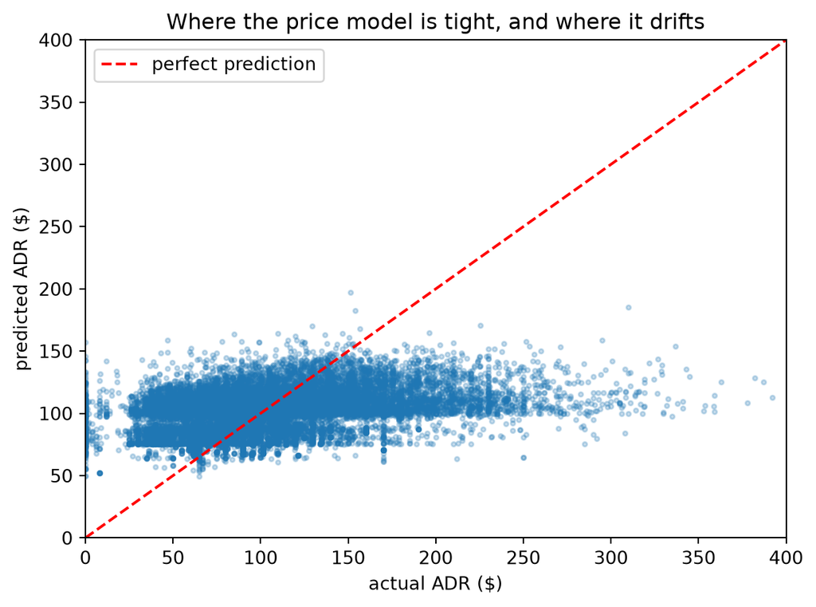

```python
# Predicted vs actual price: points on the dashed line are
# perfect predictions
pred_adr = reg_model.predict(X_reg_val, verbose=0).ravel()
plt.scatter(y_reg_val, pred_adr, s=6, alpha=0.25)
lim = [0, 400]
plt.plot(lim, lim, "r--", label="perfect prediction")
plt.xlim(lim); plt.ylim(lim)
plt.xlabel("actual ADR ($)")
plt.ylabel("predicted ADR ($)")
plt.legend()
plt.title("Where the price model is tight, and where it drifts")
plt.show();
```

> **Common Pitfall:** For regression, the output layer has **no activation** and the loss is `mse` (or `mae`), not `sigmoid` + `binary_crossentropy`. Using a sigmoid here would squash every prediction between 0 and 1.

## Walkthrough + Exercise 1.2: Use GenAI to Decode Errors and Explain Choices

Models throw confusing errors while you build them, and it isn’t always obvious why a layer is shaped the way it is. Your AI assistant is a fast debugging and explanation partner, the skill is prompting clearly and **verifying** (never trust a fix you haven’t re-run).

**A prompt to start from** (paste into your AI assistant, then iterate):

> I’m using Keras 3 on the PyTorch backend. Here is my code and the full error message: [paste]. Explain the cause in plain English, give the smallest fix, then explain in one sentence each what my hidden Dense layers and the sigmoid output layer are doing.

```python
# Scratch space for 1.2: paste an error or a model summary
# here and work with your AI assistant. (Nothing to run yet;
# this cell is yours to experiment in.)
```

> **GenAI tip:** Apply the suggested fix, then **re-run the cell** to confirm it works. If the assistant invents a function or argument, check it against the Keras docs.

### Interpretation Questions

1. The classification model reaches ~75-76% accuracy. With ~63% of bookings *not* canceled, is that a strong result? (Hint: what would “always predict not-canceled” score? We dig into this in Module 4.)
2. The regression model’s MAE is in **dollars**. Is being off by that much acceptable for a pricing decision? Where would it need to be tighter?
3. Which features would you add to improve either model, and which might be *leakage* (information you wouldn’t have at booking time)?

### Self-Check

By the end of this module, you should be able to:

- Load a business dataset and standardize numeric features for a network
- Build, compile, and train a feedforward network in Keras
- Switch a model between **classification** (sigmoid + cross-entropy) and **regression** (no activation + MSE)
- Read a falling loss curve as evidence of learning
- Recognize the same model written in idiomatic PyTorch

# Module 2: Deep Learning for Images and Customer Experience

Direct application: **auto-tagging product/food photos**, the kind of task behind delivery-app menus, retail catalogs, and visual search. We use the **Food-101** dataset and a **pre-trained** convolutional network, so we get strong results without training on millions of images ourselves (transfer learning).

## Walkthrough 2.1: Auto-Tagging Photos with a Pre-Trained CNN

### Grab a few images

```python
from datasets import load_dataset
from PIL import Image

food = load_dataset("ethz/food101", split="train",
                    streaming=True)
class_names = food.features["label"].names

samples = []
for row in food:
    samples.append(row)
    if len(samples) >= 6:
        break
print("Example categories in this dataset:",
      class_names[:8], "...")
```

```
Example categories in this dataset: ['apple_pie', 'baby_back_ribs', 'baklava', 'beef_carpaccio', 'beef_tartare', 'beet_salad', 'beignets', 'bibimbap'] ...
```

### Let a pre-trained model label them

```
%%{init: {'theme': 'base', 'themeVariables': {'fontSize': '16px'}}}%%
flowchart TD
  P[/"Raw pixels"/]:::s1 --> E["Edges & corners"]:::s2
  E --> T["Textures & shapes"]:::s3
  T --> PA["Object parts"]:::s4
  PA --> L[/"'coffee maker'"/]:::good
  classDef s1 fill:#eef4ff,stroke:#1a73e8,color:#1a1a1a
  classDef s2 fill:#cfe0ff,stroke:#1a73e8,color:#1a1a1a
  classDef s3 fill:#a9c7ff,stroke:#1a4fa0,color:#1a1a1a
  classDef s4 fill:#7fa9f5,stroke:#1a4fa0,color:#10203a
  classDef good fill:#d8f5d8,stroke:#2e7d32,color:#1a1a1a
```

A CNN builds understanding in stages, from tiny edges up to the whole object.

```python
from keras.applications.mobilenet_v2 import (
    MobileNetV2, preprocess_input, decode_predictions)

# trained on millions of images
pretrained = MobileNetV2(weights="imagenet")

def predict_label(pil_img):
    img = pil_img.convert("RGB").resize((224, 224))
    # [None] wraps one image in a batch of 1
    batch = np.array(img, dtype="float32")[None]
    # the preprocessing this model expects
    arr = preprocess_input(batch)
    top = decode_predictions(
        pretrained.predict(arr, verbose=0), top=1)[0][0]
    # (label, confidence)
    return top[1], round(float(top[2]), 2)

for row in samples[:4]:
    guess, conf = predict_label(row["image"])
    print(f"true: {class_names[row['label']]:<18} model guess: {guess} ({conf})")
```

[output not shown]

[figure not shown]

```python
# Show the images with the model's guess: seeing the
# picture makes the result land
import matplotlib.pyplot as plt
fig, axes = plt.subplots(1, 4, figsize=(12, 3.2))
for ax, row in zip(axes, samples[:4]):
    guess, conf = predict_label(row["image"])
    ax.imshow(row["image"]); ax.axis("off")
    ax.set_title(
        f"true: {class_names[row['label']]}\nguess: {guess} ({conf})",
        fontsize=9)
plt.tight_layout(); plt.show();
```

> **Common Pitfall:** Every pre-trained model expects its **own** preprocessing and input size (here 224x224 and `preprocess_input`). Skip it and predictions look random. When you swap models, swap the matching `preprocess_input`.

> **GenAI tip:** When the pre-trained model guesses a *near-miss* label (say “plate” for a pizza), paste its top guesses into an AI assistant and ask why those categories are easy to confuse, a fast way to build intuition for what the model actually “sees.”

## Exercise 2.1: Fine-Tune a Classifier for *Your* Categories

The pre-trained model knows ImageNet labels, not *your* product categories. Transfer learning fixes that: keep the model’s general “vision,” retrain only a small new head on your few categories.

```python
# Build a small labeled set from 3 food categories (your
# "product catalog")
wanted = ["pizza", "hamburger", "sushi"]
# Map each Food-101 category index to a fresh 0/1/2 label
# for our 3-class problem
want_idx = {class_names.index(name): new_label for new_label, name in enumerate(wanted)}

imgs, labels = [], []
# how many we've collected per category
counts = {category: 0 for category in want_idx}
for row in load_dataset("ethz/food101", split="train",
                        streaming=True):
    category = row["label"]
    # cap at 120 images each
    if category in want_idx and counts[category] < 120:
        imgs.append(np.array(row["image"].convert("RGB").resize((160, 160)), "float32"))
        labels.append(want_idx[category])
        counts[category] += 1
    if all(c >= 120 for c in counts.values()):
        break

X_img = np.stack(imgs)
y_img = np.array(labels)
X_img_train, X_img_val, y_img_train, y_img_val = train_test_split(
    X_img, y_img, test_size=0.25, random_state=2026,
    stratify=y_img)
print("Training images:", X_img_train.shape, "across",
      len(wanted), "categories")
```

```
Training images: (270, 160, 160, 3) across 3 categories
```

```
%%{init: {'theme': 'base', 'themeVariables': {'fontSize': '16px'}}}%%
flowchart LR
  V["Pre-trained base (FROZEN)<br/>vision from<br/>millions of images"]:::frozen --> NH["New head you train<br/>on YOUR 270 training photos"]:::accent
  NH --> OUT[/"pizza /<br/>burger /<br/>sushi"/]:::good
  classDef frozen fill:#dbe9ff,stroke:#1a73e8,stroke-width:3px,color:#1a1a1a
  classDef accent fill:#ede0ff,stroke:#6a1b9a,color:#1a1a1a
  classDef good fill:#d8f5d8,stroke:#2e7d32,color:#1a1a1a
```

Keep the giant model’s general vision frozen; train only a small new head on your own data.

```python
# Freeze the pre-trained base; train only a new
# classification head
base = MobileNetV2(input_shape=(160, 160, 3),
                   include_top=False, weights="imagenet")
base.trainable = False

clf = keras.Sequential([
    keras.layers.Input(shape=(160, 160, 3)),
    keras.layers.Lambda(preprocess_input),
    base,
    keras.layers.GlobalAveragePooling2D(),
    keras.layers.Dropout(0.2),
    keras.layers.Dense(len(wanted), activation="softmax"),
])
clf.compile(optimizer="adam",
            loss="sparse_categorical_crossentropy",
            metrics=["accuracy"])
clf.fit(X_img_train, y_img_train,
        validation_data=(X_img_val, y_img_val), epochs=5,
        batch_size=16, verbose=0)
print(
    "Validation accuracy:",
    round(float(clf.evaluate(X_img_val, y_img_val, verbose=0)[1]), 3))
```

[output not shown]

[figure not shown]

```python
# Show 6 validation photos with the fine-tuned model's call
# (green = right, red = wrong)
val_pred = clf.predict(X_img_val, verbose=0).argmax(axis=1)
fig, axes = plt.subplots(1, 6, figsize=(14, 2.8))
for ax, img, true_i, pred_i in zip(axes, X_img_val[:6],
                                   y_img_val[:6],
                                   val_pred[:6]):
    ax.imshow(img.astype("uint8")); ax.axis("off")
    ok = (true_i == pred_i)
    ax.set_title(f"{wanted[pred_i]}",
                 color="green" if ok else "red",
                 fontsize=10)
plt.suptitle("Fine-tuned model on YOUR categories")
plt.tight_layout()
plt.show();
```

> **Common Pitfall:** Keep the pre-trained base **frozen** (`base.trainable = False`) when you have little data. Unfreezing everything with a few hundred images usually overfits fast and *erases* the valuable general features.

### Idiomatic PyTorch (reference): transfer learning with torchvision

```python
# Equivalent pattern in raw PyTorch (run in an environment
# with torchvision):
import torch, torch.nn as nn
from torch.utils.data import TensorDataset, DataLoader
from torchvision import models, transforms

weights = models.MobileNet_V2_Weights.IMAGENET1K_V1
net = models.mobilenet_v2(weights=weights)
for p in net.parameters():            # freeze the base
    p.requires_grad = False
# new head
net.classifier[1] = nn.Linear(net.last_channel, len(wanted))

# the model's own preprocessing
prep = weights.transforms()
# only the head has gradients
opt = torch.optim.Adam(net.classifier.parameters(), lr=1e-3)
# expects raw logits + integer labels
loss_fn = nn.CrossEntropyLoss()

# Reuse the same images/labels; torchvision wants channels-
# first tensors in [0, 1]
# NHWC -> NCHW
X_img_train_t = torch.tensor(X_img_train).permute(0, 3, 1, 2) / 255.0
X_img_val_t = torch.tensor(X_img_val).permute(0, 3, 1, 2) / 255.0
y_img_train_t = torch.tensor(y_img_train)
y_img_val_t = torch.tensor(y_img_val)

train_loader = DataLoader(
    TensorDataset(X_img_train_t, y_img_train_t),
    batch_size=16, shuffle=True)

# Same training loop shape as Modules 1 and 3
for epoch in range(5):
    net.train()
    for x_batch, y_batch in train_loader:
        # clear last step's gradients
        opt.zero_grad()
        # prep applies the model's normalization
        loss = loss_fn(net(prep(x_batch)), y_batch)
        # measure how to improve
        loss.backward()
        # nudge the head's weights
        opt.step()

# Evaluate the same way as the Keras model above
net.eval()
with torch.no_grad():
    logits = net(prep(X_img_val_t))
    val_acc = (logits.argmax(1) == y_img_val_t).float().mean().item()
print("PyTorch validation accuracy:", round(val_acc, 3))
```

[output not shown]

## Walkthrough + Exercise 2.2: Use GenAI to Explain Layers and Suggest Improvements

Use your AI assistant to demystify a model’s architecture and weigh changes for your own use case. Then test, don’t just trust.

**A prompt to start from:**

> Here is my Keras model summary: [paste the output of `clf.summary()`]. Explain what each layer does in business terms. Then suggest one change to improve accuracy and one to make the model smaller or faster, and describe the trade-offs of each.

```python
# Scratch space for 2.2: paste clf.summary() output here,
# or try a suggested tweak.
```

> **GenAI tip:** Apply only ONE suggested change at a time and re-evaluate, so you can see what actually helped.

### Interpretation Questions

1. The pre-trained model often guesses a *close* ImageNet label (e.g. “plate”, “pizza”) even before fine-tuning. Why is that “general vision” so reusable?
2. With only 120 images per class, fine-tuning still does well. What does that imply for a small business that can’t label millions of photos?
3. Where would automated image tagging save real time in your organization?

### Self-Check

By the end of this module, you should be able to:

- Use a pre-trained CNN to classify images with the correct preprocessing
- Explain transfer learning in business terms (“reuse, don’t reinvent”)
- Fine-tune a frozen base on a small set of your own categories
- Recognize when freezing the base prevents overfitting

# Module 3: Deep Learning for Text and Customer Sentiment

Direct application: **reading customer sentiment at scale** from reviews and support text. We use real **Yelp business reviews**.

## Walkthrough 3.1: Sentiment from Reviews with Word Embeddings

### Load real reviews

```python
from datasets import load_dataset

stream = load_dataset("fancyzhx/yelp_polarity",
                      split="train", streaming=True)
texts, sentiments = [], []
for i, row in enumerate(stream):
    # 0 = negative, 1 = positive
    texts.append(row["text"])
    sentiments.append(row["label"])
    if i >= 5999:
        break
sentiments = np.array(sentiments, dtype="float32")
print("Loaded", len(texts), "reviews. Example:")
print(texts[0][:160], "...")
```

```
Loaded 6000 reviews. Example:
Unfortunately, the frustration of being Dr. Goldberg's patient is a repeat of the experience I've had with so many other doctors in NYC -- good doctor, terrible ...
```

### Turn words into numbers (a simple tokenizer)

```
%%{init: {'theme': 'base', 'themeVariables': {'fontSize': '16px'}}}%%
flowchart TD
  R[/"Raw review:<br/>'great food,<br/>slow service'"/]:::data --> T["Tokens to<br/>integer IDs"]:::proc
  T --> PD["Pad to a<br/>fixed length"]:::proc
  PD --> EM["Embedding:<br/>meaning as numbers"]:::accent
  EM --> AV["Average the<br/>word vectors"]:::proc
  AV --> O[/"Positive /<br/>Negative"/]:::good
  classDef data fill:#d1f0ec,stroke:#0b7a75,color:#1a1a1a
  classDef proc fill:#dbe9ff,stroke:#1a73e8,color:#1a1a1a
  classDef accent fill:#ede0ff,stroke:#6a1b9a,color:#1a1a1a
  classDef good fill:#d8f5d8,stroke:#2e7d32,color:#1a1a1a
```

From messy text to a sentiment call: tokenize, pad, embed, pool, predict.

```python
from collections import Counter

def build_vocab(texts, max_tokens=10000):
    # Count how often each word appears across every review
    counts = Counter(word for text in texts for word in text.lower().split())
    # Give each common word an ID, starting at 2 so 0 stays
    # "padding" and 1 stays "unknown"
    return {word: i + 2 for i, (word, _) in enumerate(counts.most_common(max_tokens - 2))}

def encode(texts, vocab, max_len=150):
    # rows of zeros = pre-padded
    out = np.zeros((len(texts), max_len), dtype="int64")
    for i, text in enumerate(texts):
        # 1 = unknown word
        ids = [vocab.get(word, 1) for word in text.lower().split()][:max_len]
        out[i, :len(ids)] = ids
    return out

VOCAB_SIZE, MAX_LEN = 10000, 150
vocab = build_vocab(texts, VOCAB_SIZE)
X_text = encode(texts, vocab, MAX_LEN)
X_text_train, X_text_val, y_text_train, y_text_val = train_test_split(
    X_text, sentiments, test_size=0.2, random_state=2026,
    stratify=sentiments)
print("Encoded shape:", X_text.shape)
```

```
Encoded shape: (6000, 150)
```

> **The TensorFlow-powered alternative:** Keras 3 ships a convenience layer, `keras.layers.TextVectorization`, that does this tokenizing for you. It is powered by **TensorFlow** under the hood, so it needs TensorFlow available even on the PyTorch backend, Colab already ships it. We hand-rolled the tokenizer above to show exactly what “turning text into numbers” means; here is the one-layer TensorFlow version doing the same job:

```python
# TensorFlow-backed text vectorization. Colab ships
# TensorFlow, so this runs as-is.
from keras.layers import TextVectorization

vectorizer = TextVectorization(
    max_tokens=VOCAB_SIZE, output_sequence_length=MAX_LEN)
# learns the vocabulary from the reviews (via TF)
vectorizer.adapt(texts)
demo = vectorizer(["the staff were friendly and the food arrived hot"])
# (1, MAX_LEN)
print("TextVectorization output shape:", tuple(demo.shape))
print("First 12 token IDs:", [int(t) for t in demo[0][:12]])
```

[output not shown]

> The hand-built `encode()` and this TensorFlow layer do the same job, map words to integer IDs and pad to a fixed length. So the embedding model below trains on either.

### Build an embedding model

```python
text_model = keras.Sequential([
    keras.layers.Input(shape=(MAX_LEN,)),
    # the "meaning as numbers" map
    keras.layers.Embedding(VOCAB_SIZE, 32),
    keras.layers.GlobalAveragePooling1D(),
    keras.layers.Dense(32, activation="relu"),
    keras.layers.Dense(1, activation="sigmoid"),
])
text_model.compile(optimizer="adam",
                   loss="binary_crossentropy",
                   metrics=["accuracy"])
text_hist = text_model.fit(
    X_text_train, y_text_train,
    validation_data=(X_text_val, y_text_val), epochs=5,
    batch_size=64, verbose=0)
print(
    "Validation accuracy:",
    round(float(text_hist.history["val_accuracy"][-1]), 3))
```

```
Validation accuracy: 0.863
```

### Try it on your own sentences

```python
def sentiment_of(sentence):
    ids = encode([sentence], vocab, MAX_LEN)
    p = float(text_model.predict(ids, verbose=0)[0][0])
    return f"{'positive' if p > 0.5 else 'negative'} ({p:.2f})"

for s in ["The staff were friendly and the food arrived hot",
          "Waited an hour and the order was completely wrong"]:
    print(sentiment_of(s), "<-", s)
```

```
positive (0.62) <- The staff were friendly and the food arrived hot
negative (0.31) <- Waited an hour and the order was completely wrong
```

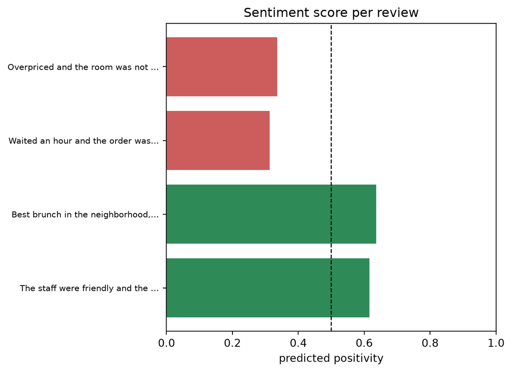

```python
# A bar chart turns raw probabilities into something you can
# show a stakeholder
examples = ["The staff were friendly and the food arrived hot",
            "Best brunch in the neighborhood, will be back",
            "Waited an hour and the order was completely wrong",
            "Overpriced and the room was not clean"]
scores = [float(text_model.predict(encode([s], vocab, MAX_LEN), verbose=0)[0][0])
          for s in examples]
colors = ["seagreen" if p > 0.5 else "indianred" for p in scores]
plt.barh(range(len(examples)), scores, color=colors)
plt.yticks(range(len(examples)),
           [s[:32] + "..." for s in examples], fontsize=8)
plt.axvline(0.5, color="k", ls="--", lw=1)
plt.xlabel("predicted positivity"); plt.xlim(0, 1)
plt.title("Sentiment score per review")
plt.tight_layout()
plt.show();
```